# Mi primer reporte en R Markdown

Alvaro Chirino Gutierrez

Octubre, 2020

# Motivación

## Alcances

1. Alcance 1
2. Alcance 2
3. Alcance 3
4. Alcance 4

## Metodología

Se plantea un modelo del tipo:

$$y_i= \beta_0+\beta_1x_i+\epsilon_i$$
El modelo $y_i= \beta_0+\beta_1x_i+\epsilon_i$

$$F(t)=\int_0^t f(x)dx$$

| Casos | Método | Población | Periodo |
| --- | --- | --- | --- |
| Caso 1 | muestra | aves | 2018 |
| Caso 2 | experimento | hormigas | 2013 |

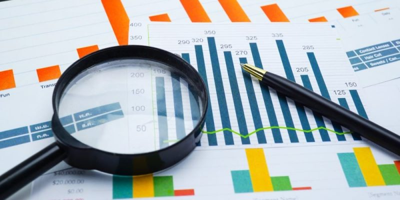

Estadística descriptiva

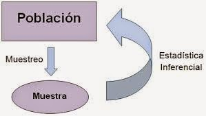

# Resultados

Los entornos para introducir código R se llaman Chunks

```
##     Min.  1st Qu.   Median     Mean  3rd Qu.     Max.
## -3.49931 -0.65286  0.02359  0.02777  0.71189  3.28300
```

Acá vemos un gráfico

```
## y
##   0   1   2   3   4   5   6   7   8   9
##  25 134 218 267 214  93  42   5   1   1
```

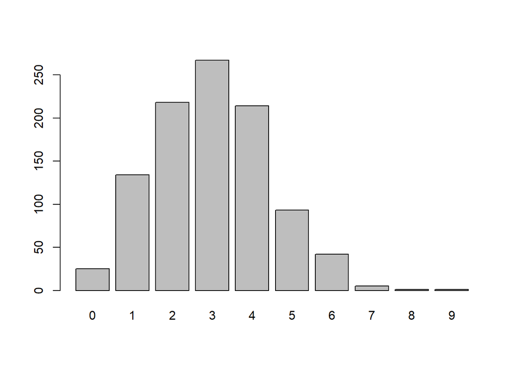

```r
plot(density(x))
```

[output not shown]

A partir del resultado del estudio se tiene 13, también el vector de datos 1, 2, 3, 4, 5, 6, 7, 8, 9, 10, 11, 12, 13, 14, 15, 16, 17, 18, 19, 20, 21, 22, 23, 24, 25, 26, 27, 28, 29, 30, 31, 32, 33, 34, 35, 36, 37, 38, 39, 40, 41, 42, 43, 44, 45, 46, 47, 48, 49, 50, 51, 52, 53, 54, 55, 56, 57, 58, 59, 60, 61, 62, 63, 64, 65, 66, 67, 68, 69, 70, 71, 72, 73, 74, 75, 76, 77, 78, 79, 80, 81, 82, 83, 84, 85, 86, 87, 88, 89, 90, 91, 92, 93, 94, 95, 96, 97, 98, 99, 100. La dimensión de $Y$ es 1000.

```r
library(knitr)
t1<-table(y,y)
t1
```

```
##    y
## y     0   1   2   3   4   5   6   7   8   9
##   0  25   0   0   0   0   0   0   0   0   0
##   1   0 134   0   0   0   0   0   0   0   0
##   2   0   0 218   0   0   0   0   0   0   0
##   3   0   0   0 267   0   0   0   0   0   0
##   4   0   0   0   0 214   0   0   0   0   0
##   5   0   0   0   0   0  93   0   0   0   0
##   6   0   0   0   0   0   0  42   0   0   0
##   7   0   0   0   0   0   0   0   5   0   0
##   8   0   0   0   0   0   0   0   0   1   0
##   9   0   0   0   0   0   0   0   0   0   1
```

```r
kable(t1)#tabla
```

|  | 0 | 1 | 2 | 3 | 4 | 5 | 6 | 7 | 8 | 9 |
| --- | --- | --- | --- | --- | --- | --- | --- | --- | --- | --- |
| 0 | 25 | 0 | 0 | 0 | 0 | 0 | 0 | 0 | 0 | 0 |
| 1 | 0 | 134 | 0 | 0 | 0 | 0 | 0 | 0 | 0 | 0 |
| 2 | 0 | 0 | 218 | 0 | 0 | 0 | 0 | 0 | 0 | 0 |
| 3 | 0 | 0 | 0 | 267 | 0 | 0 | 0 | 0 | 0 | 0 |
| 4 | 0 | 0 | 0 | 0 | 214 | 0 | 0 | 0 | 0 | 0 |
| 5 | 0 | 0 | 0 | 0 | 0 | 93 | 0 | 0 | 0 | 0 |
| 6 | 0 | 0 | 0 | 0 | 0 | 0 | 42 | 0 | 0 | 0 |
| 7 | 0 | 0 | 0 | 0 | 0 | 0 | 0 | 5 | 0 | 0 |
| 8 | 0 | 0 | 0 | 0 | 0 | 0 | 0 | 0 | 1 | 0 |
| 9 | 0 | 0 | 0 | 0 | 0 | 0 | 0 | 0 | 0 | 1 |

```r
library(DT)# dataframe
datatable(cars)
```

|  | speed | dist |
| --- | --- | --- |
| 1 | 4 | 2 |
| 2 | 4 | 10 |
| 3 | 7 | 4 |
| 4 | 7 | 22 |
| 5 | 8 | 16 |
| 6 | 9 | 10 |
| 7 | 10 | 18 |
| 8 | 10 | 26 |
| 9 | 10 | 34 |
| 10 | 11 | 17 |

[output cut: 40 more lines]